# Basic_visual_Homework_2

Ivan Derkachev

2024-10-20

## Загрузка данных

```r
data <- read_csv("hogwarts_2024.csv")
```

```r
data <- data |> mutate(
  across(c(house, course, sex, wandCore, bloodStatus), ~ as.factor(.x)))
```

## Диаграммы рассеяния (скаттерплоты)

### 1 задание

Постройте скаттерплот, визуализирующий связь между суммарным баллом студента за год и оценкой за экзамен по травологии. Добавьте на график линию тренда. Удалите доверительную область и сделайте линию прямой. Подумайте, как избежать того, чтобы записать одни и те же координаты x и y дважды. Проинтерпретируйте график. (1 б.)

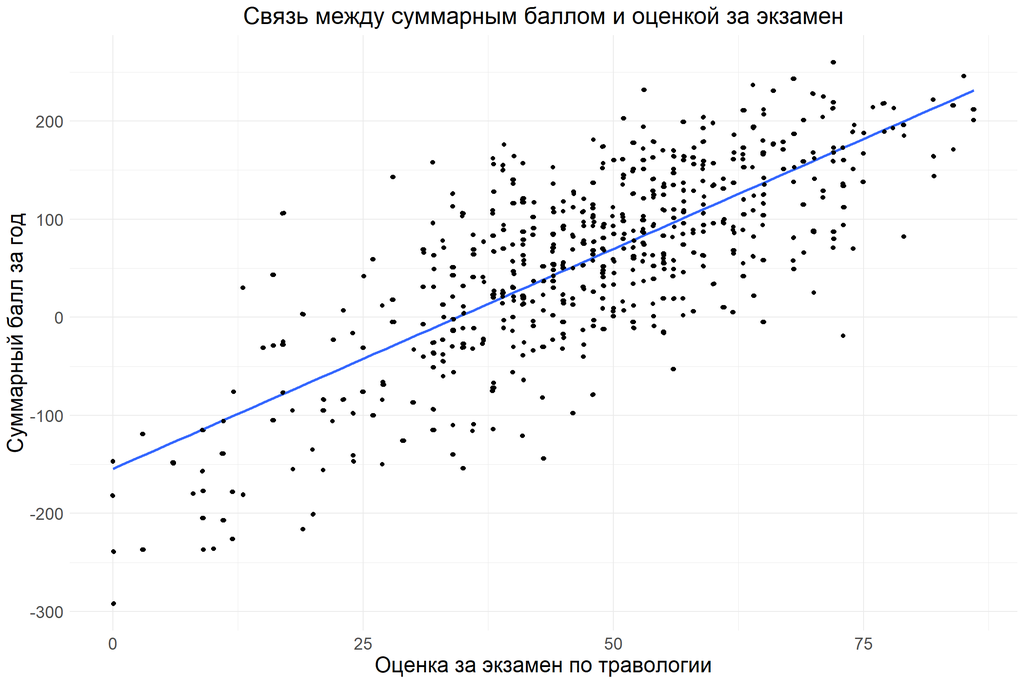

```r
ggplot(data, aes(x = `Herbology exam`, y = result)) +
  geom_point(position = position_jitter(width = 0.1, height = 0.1)) +
  geom_smooth(method = "lm", se = FALSE) +
  theme_minimal() +
  geom_jitter(width = 0.1, height = 0.1) +
  labs(x = "Оценка за экзамен по травологии",
       y = "Суммарный балл за год",
       title = "Связь между суммарным баллом и оценкой за экзамен") +
  theme(text = element_text(size = 18),
        plot.title = element_text(size = 20, hjust = 0.5))
```

**На графике видно положительную взаимосвзяь между итоговым баллом и оценкой.**

### 2 задание

Отобразите на одной иллюстрации скаттерплоты, аналогичные тому, что вы делали на первом задании, для экзаменов по травологии, магловедению, прорицаниям и зельеварению. На иллюстрации также должна присутствовать линия тренда с характеристиками, аналогичными тем, что были в пункте 1. Раскрасьте точки в разные цвета, в соответствии с факультетами. Используйте стандартные цвета факультетов (как в лекционных rmd). Проинтерпретируйте полученный результат. (1 б). Если вы создадите иллюстрацию из этого пункта, используя только пакеты семейства tidyverse, и не привлекая дополнительные средства, вы получите дополнительные 0.5 б.

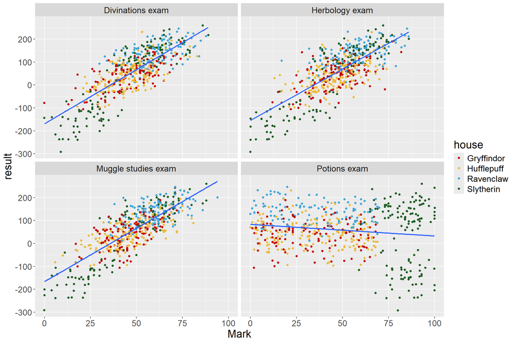

```r
data %>%
  pivot_longer(cols = c(`Herbology exam`, `Muggle studies exam`, `Divinations exam`,`Potions exam`),
               names_to = "Exam", values_to = "Mark") %>%
  ggplot(aes(x = Mark, y = result)) +
  geom_point(aes(color = house),
             position = position_jitter(width = 0.1, height = 0.1)) +
  geom_smooth(method = "lm", se = FALSE) +
  scale_color_manual(values = c("Gryffindor" = "#C50000",
                                "Hufflepuff" = "#ECB939",
                                "Ravenclaw" = "#41A6D9",
                                "Slytherin" = "#1F5D25")) +
  theme(text = element_text(size = 18),
        plot.title = element_text(size = 20, hjust = 0.5)) +
  facet_wrap(~ Exam)
```

**На графике видно положительную взаимосвзяь между итоговым баллом и оценкой по травологии, магловедению и прорицаниям. Итоговый балл имеет отрицательную взаимосвязь с оценкой по зельеварению.**

### 3 задание

Видоизмените график, полученный на предыдущем шаге. Сгруппируйте и покрасьте линии тренда в соответствии с одной из категориальных переменных (с такой, которая подсвечивает одно из наблюдений на предыдущем этапе, относящееся ко всем 4-м экзаменам). Постарайтесь избежать коллизий в легенде, при этом сохранив и цветовую палитру для раскраски точек по факультетам. (1 б.)

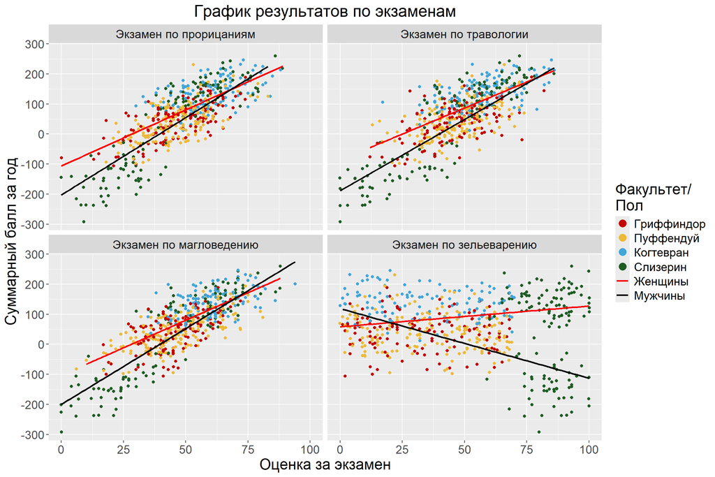

```r
data %>%
  pivot_longer(cols = c(`Herbology exam`, `Muggle studies exam`, `Divinations exam`,`Potions exam`),
               names_to = "Exam", values_to = "Mark") %>%
  ggplot(aes(x = Mark, y = result)) +
  geom_point(aes(colour = house),
             position = position_jitter(width = 0.1, height = 0.1)) +
  geom_smooth(aes(color = sex),
              method = "lm", se = FALSE) +
  scale_color_manual(name = "Факультет/\nПол",
                     values = c("Gryffindor" = "#C50000",
                                "Hufflepuff" = "#ECB939",
                                "Ravenclaw" = "#41A6D9",
                                "Slytherin" = "#1F5D25",
                                "male" = "black",
                                "female" = "red"),
                     labels = c("Gryffindor" = "Гриффиндор",
                                "Hufflepuff" = "Пуффендуй",
                                "Ravenclaw" = "Когтевран",
                                "Slytherin" = "Слизерин",
                                "male" = "Мужчины",
                                "female" = "Женщины"))  +
  labs(title = "График результатов по экзаменам",
       x = "Оценка за экзамен",
       y = "Суммарный балл за год")  +
  theme(text = element_text(size = 18),
        plot.title = element_text(size = 20, hjust = 0.5)) +
  facet_wrap(~ Exam,
             labeller = labeller(Exam = c(`Herbology exam` = "Экзамен по травологии",
                                          `Muggle studies exam` = "Экзамен по магловедению",
                                          `Divinations exam`= "Экзамен по прорицаниям",
                                          `Potions exam`= "Экзамен по зельеварению"))) +
  guides(color = guide_legend(override.aes = list(size = 4)))
```

## geom_col и вещи вокруг него

### 1 задание

Постройте барплот (столбиковую диаграмму) распределения набранных баллов за первый семестр (с 1-й по 17-ю неделю включительно) у студентов разного происхождения. Если у вас возникают трудности,

можете обратиться к шпаргалке по dplyr от posit. Выдвиньте гипотезу (или гипотезы), почему распределение получилось именно таким. (1 б.)

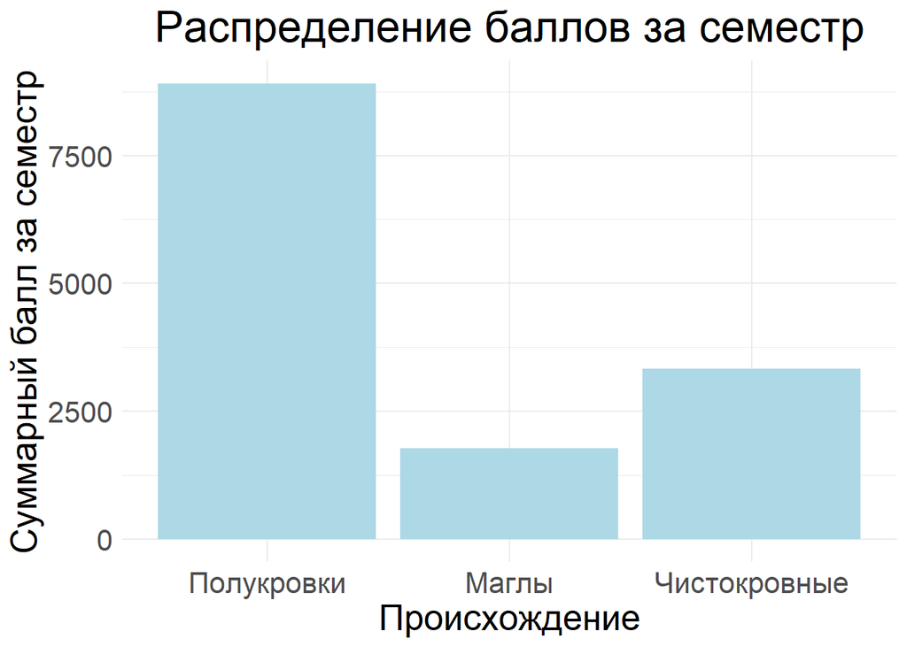

```r
data %>%
  mutate(semestr_score = rowSums(select(., matches("^week_([1-9]|1[0-7])$")), , na.rm = TRUE)) %>%
  ggplot(aes(x = bloodStatus, y = semestr_score)) +
  stat_summary(fun = sum, geom = "bar", fill = "lightblue") +
  labs(title = "Распределение баллов за семестр",
       x = "Происхождение",
       y = "Суммарный балл за семестр") +
  theme_minimal() +
  theme(text = element_text(size = 20),
        plot.title = element_text(hjust = 0.5)) +
  scale_x_discrete(labels = c("muggle-born" = "Маглы",
                              "half-blood" = "Полукровки",
                              "pure-blood" = "Чистокровные"))
```

**На распределение баллов может влиять разное количество студентов по происхождению. Чтобы проверить построим гистограмму для визуализации количества студентов по происхождению.**

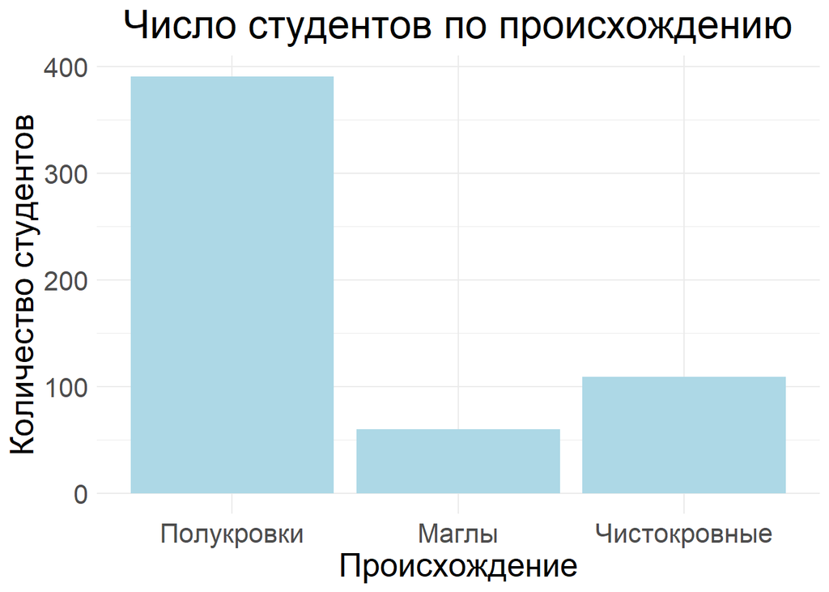

```r
ggplot(data, aes(x = bloodStatus)) +
  geom_bar(fill = "lightblue") +
  labs(title = "Число студентов по происхождению",
       x = "Происхождение", y = "Количество студентов") +
  theme_minimal() +
  theme(text = element_text(size = 20),
        plot.title = element_text(hjust = 0.5)) +
  scale_x_discrete(labels = c("muggle-born" = "Маглы",
                              "half-blood" = "Полукровки",
                              "pure-blood" = "Чистокровные"))
```

**Действительно, имеется большое различие числа студентов.Полукровок почти 400!** **Можно посмотерть средние значения, чтобы увидеть более адекватный показатель.**

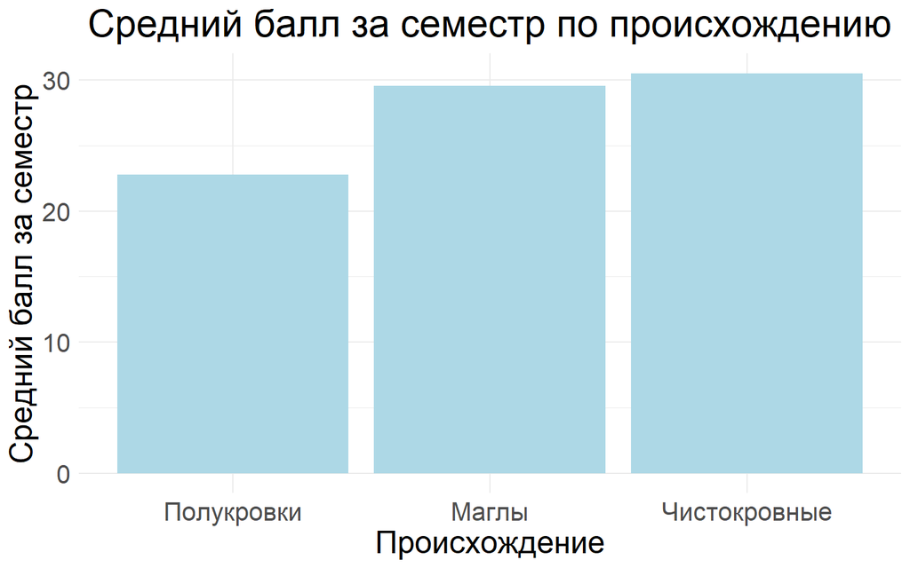

```r
data %>%
  mutate(semestr_score = rowSums(select(., matches("^week_([1-9]|1[0-7])$")), , na.rm = TRUE)) %>%
  ggplot(aes(x = bloodStatus, y = semestr_score)) +
  stat_summary(fun = mean, geom = "bar", fill = "lightblue") +
  labs(title = "Средний балл за семестр по происхождению",
       x = "Происхождение",
       y = "Средний балл за семестр") +
  theme_minimal() +
  theme(text = element_text(size = 20),
        plot.title = element_text(hjust = 0.5)) +
  scale_x_discrete(labels = c("muggle-born" = "Маглы",
                              "half-blood" = "Полукровки",
                              "pure-blood" = "Чистокровные"))
```

### Задание 2

Модифицируйте предыдущий график – отсортируйте столбцы в порядке убывания суммы баллов. Добавьте на график текстовые метки, отражающие число студентов каждого происхождения. Попробуйте использовать для этой задачи не geom_text, а geom_label. Настройте внешний вид geom_label по своему усмотрению. Поправьте название оси. Проинтерпретируйте график. Соотносится ли интерпретация с вашей гипотезой из пункта 1? (1 б.)

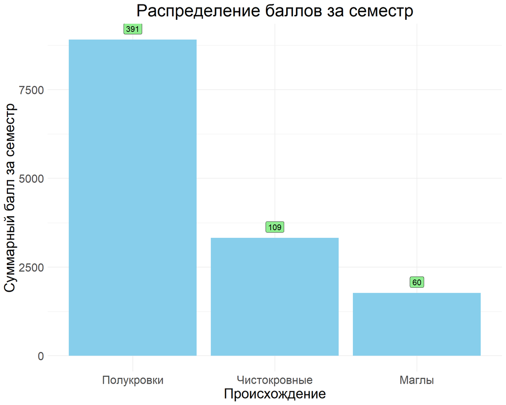

```r
data %>%
  mutate(semestr_score = rowSums(select(., matches("^week_([1-9]|1[0-7])$")), na.rm = TRUE)) %>%
  group_by(bloodStatus) %>%
  summarise(total_score = sum(semestr_score, na.rm = TRUE),
            student_count = n()) %>%
  arrange(desc(total_score)) %>%
  ggplot(aes(x = reorder(bloodStatus, -total_score), y = total_score)) +
  geom_bar(stat = "identity", fill = "skyblue") +
  geom_label(aes(label = student_count),
             color = "black",
             fill = "lightgreen",
             size = 4,
             vjust = -0.5) +
  labs(title = "Распределение баллов за семестр",
       x = "Происхождение",
       y = "Суммарный балл за семестр") +
  theme_minimal() +
  theme(text = element_text(size = 20),
        plot.title = element_text(hjust = 0.5)) +
  scale_x_discrete(labels = c("muggle-born" = "Маглы",
                              "half-blood" = "Полукровки",
                              "pure-blood" = "Чистокровные"))
```

**Результат соотносится с гипотезой.**

### 3 задание

И снова измените график – добавьте на него разбивку не только по происхождению, но и по полу. Раскрасьте столбцы по происхождению. Сделайте подписи к столбцам читаемыми. Дайте графику название, измените, если требуется, название осей. Сделайте шаг для оси, на которой отображены очки, через каждую тысячу баллов. Разместите текстовые метки по правому краю графика. Настройте график таким образом, чтобы метки были видны целиком и не обрезались. Сохраните график на устройство.(1.5 б.)

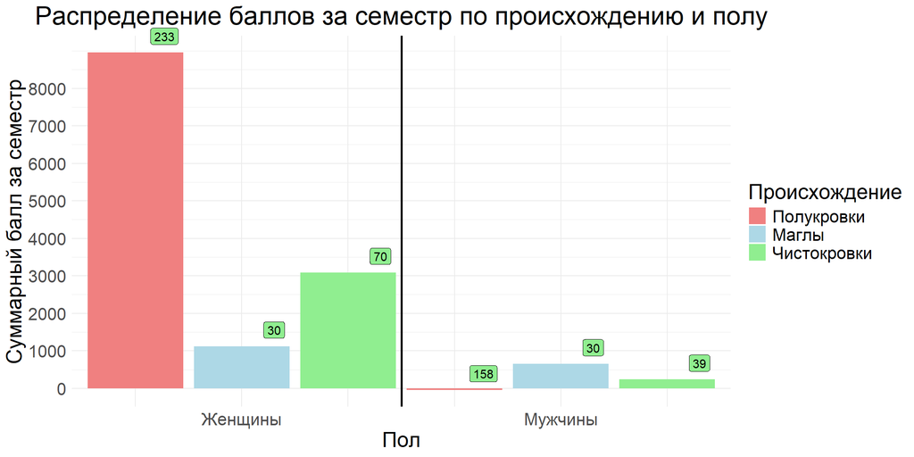

```r
processed_data <- data %>%
  mutate(semestr_score = rowSums(select(., matches("^week_([1-9]|1[0-7])$")), na.rm = TRUE)) %>%
  group_by(bloodStatus, sex) %>%
  summarise(total_score = sum(semestr_score, na.rm = TRUE),
            student_count = n(), .groups = 'drop') %>%
  arrange(desc(total_score))


processed_data %>%
  ggplot(aes(x = interaction(bloodStatus, sex), y = total_score, fill = bloodStatus)) +
  geom_bar(stat = "identity", position = position_stack()) +
  geom_label(aes(label = student_count),
             position = position_nudge(x = 0.4),
             color = "black",
             fill = "lightgreen",
             size = 4,
             hjust = 1,
             vjust = -0.5) +
  labs(title = "Распределение баллов за семестр по происхождению и полу",
       x = "Пол",
       y = "Суммарный балл за семестр") +
  scale_y_continuous(breaks = seq(0, max(processed_data$total_score, na.rm = TRUE), by = 1000)) +
  theme_minimal() +
  theme(text = element_text(size = 20),
        plot.title = element_text(hjust = 0.5)) +
  scale_fill_manual(name = "Происхождение",
                    values = c("muggle-born" = "lightblue",
                               "half-blood" = "lightcoral",
                               "pure-blood" = "lightgreen"),
                    labels = c("muggle-born" = "Маглы",
                               "half-blood" = "Полукровки",
                               "pure-blood" = "Чистокровки")) +
  scale_x_discrete(labels = c("muggle-born.female" = "Женщины",
                              "half-blood.female" = "",
                              "pure-blood.female" = "",
                              "muggle-born.male" = "Мужчины",
                              "half-blood.male" = "",
                              "pure-blood.male" = "")) +
  geom_vline(xintercept = 3.5, size = 1) +
  coord_cartesian(clip = "off")
```

### Здадание 4

Функция coord_flip() используется для транспонирования, что позволяет отображать данные в горизонтальном виде. Это может быть особенно полезно когда метки на оси x длинные, их проще читать в горизонтальном формате и можно избежать наложений текста.

Иногда изменение ориентации может затруднить интерпретацию данных, особенно если зрители привыкли к стандартной вертикальной ориентации. Также горизонтальные графики могут занять больше места по вертикали, что может стать проблемой при ограниченном пространстве на странице.

## Разное

### 1 задание

Сравните распределение баллов за экзамен по зельеварению и за экзамен по древним рунам. Сделайте это тремя разными способами. Под разными способами понимаются идеологически разные геомы или способы группировки. Не считаются разными способами изменения константных визуальных параметров (цвет заливки, размер фигур) на сходных в остальном графиках. Объедините графики, таким образом, чтобы результирующий график имел два столбца и 2 строки. Два графика должны находиться в верхней строке и занимать равную площадь. Третий график должен занимать нижнюю строку целиком. (2 б).

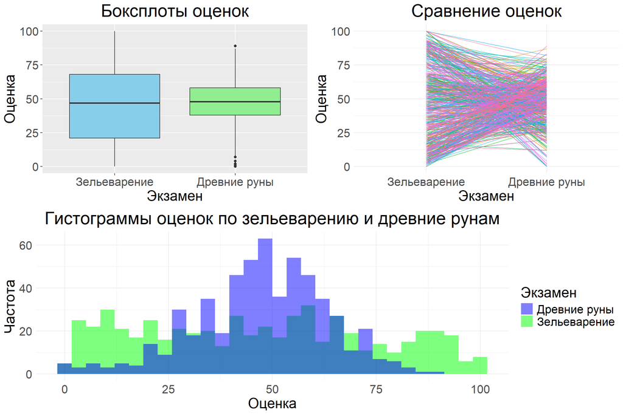

```r
histogram_plot <-
  ggplot(data) +
  geom_histogram(aes(x = `Potions exam`, fill = "Зельеварение"),
                 alpha = 0.5,
                 position = "identity") +
  geom_histogram(aes(x = `Study of ancient runes exam`, fill = "Древние руны"),
                 alpha = 0.5,
                 position = "identity") +
    labs(title = "Гистограммы оценок по зельеварению и древние рунам",
         x = "Оценка",
         y = "Частота") +
    theme_minimal() +
    theme(text = element_text(size = 20),
          plot.title = element_text(hjust = 0.5)) +
    scale_fill_manual(name = "Экзамен",
                      values = c("blue","green"))


line_plot <- data %>%
  melt(data, id.vars = "id",
       measure.vars = c("Potions exam", "Study of ancient runes exam"),
       variable.name = "Exam", value.name = "Score") %>%
  mutate(Exam = recode(Exam,
                       `Potions exam` = "Зельеварение",
                       `Study of ancient runes exam` = "Древние руны")) %>%
  ggplot(aes(x = Exam, y = Score, group = id)) +
  geom_line(aes(color = as.factor(id)), alpha = 0.6) +
  labs(title = "Сравнение оценок",
       x = "Экзамен", y = "Оценка") +
  theme_minimal() +
  theme(text = element_text(size = 20),
        plot.title = element_text(hjust = 0.5),
        legend.position = "none")



box_plot <- data %>%
  melt(measure.vars = c("Potions exam", "Study of ancient runes exam"),
       variable.name = "Exam", value.name = "Score") %>%
  mutate(Exam = recode(Exam,
                       `Potions exam` = "Зельеварение",
                       `Study of ancient runes exam` = "Древние руны")) %>%
  ggplot(aes(x = Exam, y = Score, fill = Exam)) +
  geom_boxplot() +
  labs(title = "Боксплоты оценок", x = "Экзамен", y = "Оценка") +
  scale_fill_manual(values = c("Зельеварение" = "skyblue", "Древние руны" = "lightgreen")) +
  theme(legend.position = "none",
        text = element_text(size = 20),
        plot.title = element_text(hjust = 0.5))

grid.arrange(box_plot, line_plot, histogram_plot, ncol = 2, nrow = 2, layout_matrix = rbind(c(1, 2), c(3, 3)))
```

### 2 задание

Визуализируйте средний балл по зельеварению студентов с различным происхождением. Вы вольны добавить дополнительные детали и информацию на график. Проинтерпретируйте результат. Как вы думаете, почему он именно такой? Если у вас есть гипотеза, проиллюстрируйте ее еще одним графиком (или графиками). Объедините их при помощи ggarrange. (по 1 б. за первый и график и правильную интерпретацию с подтверждением в виде второго графика и текстовой аргументации). Измените порядок ваших фигур на первом графике слева направо следующим образом: маглорожденные,, чистокровные, полукровки.

Скорректируйте название оси. Если у вас возникают сложности, обратитесь к шпаргалке по пакету forcats от posit. (Дополнительные 0.5 б.)

#### 1 график

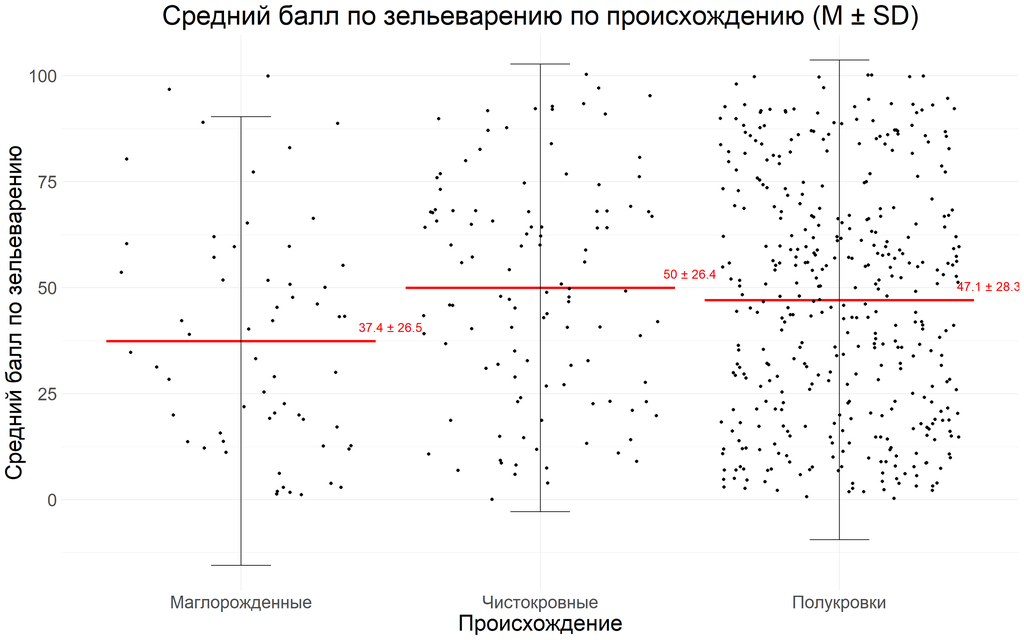

```r
summary_data <- data %>%
  mutate(bloodStatus = recode(bloodStatus,
                              "muggle-born" = "Маглорожденные",
                              "pure-blood" = "Чистокровные",
                              "half-blood" = "Полукровки")) %>%
  mutate(bloodStatus = fct_relevel(bloodStatus,
                                   "Маглорожденные",
                                   "Чистокровные",
                                   "Полукровки")) %>%
  group_by(bloodStatus) %>%
  summarise(mean_value = mean(`Potions exam`, na.rm = TRUE),
            sd_value = sd(`Potions exam`, na.rm = TRUE))

data %>%
  mutate(bloodStatus = recode(bloodStatus,
                              "muggle-born" = "Маглорожденные",
                              "pure-blood" = "Чистокровные",
                              "half-blood" = "Полукровки")) %>%
  mutate(bloodStatus = fct_relevel(bloodStatus,
                                   "Маглорожденные",
                                   "Чистокровные",
                                   "Полукровки")) %>%
  ggplot(aes(x = bloodStatus, y = `Potions exam`)) +
  stat_summary(fun = mean, geom = "crossbar", color = "red", size = 0.5) +
  stat_summary(fun.data = mean_sdl, geom = "errorbar", width = 0.2) +
  geom_jitter() +
  geom_text(data = summary_data,
            aes(x = bloodStatus,
                y = mean_value,
                label = paste0(round(mean_value, 1), " ± ", round(sd_value, 1))),
            vjust = -1, color = "red", size = 5,
            position = position_nudge(x = 0.5)) +
  labs(x = "Происхождение", y = "Средний балл по зельеварению", title = "Средний балл по зельеварению по происхождению (M ± SD)") +
  theme_minimal() +
  theme(text = element_text(size = 25),
        plot.title = element_text(hjust = 0.5))
```

**Средний балл по зельеварению немного ниже у маглорожденных.**

#### 2 график

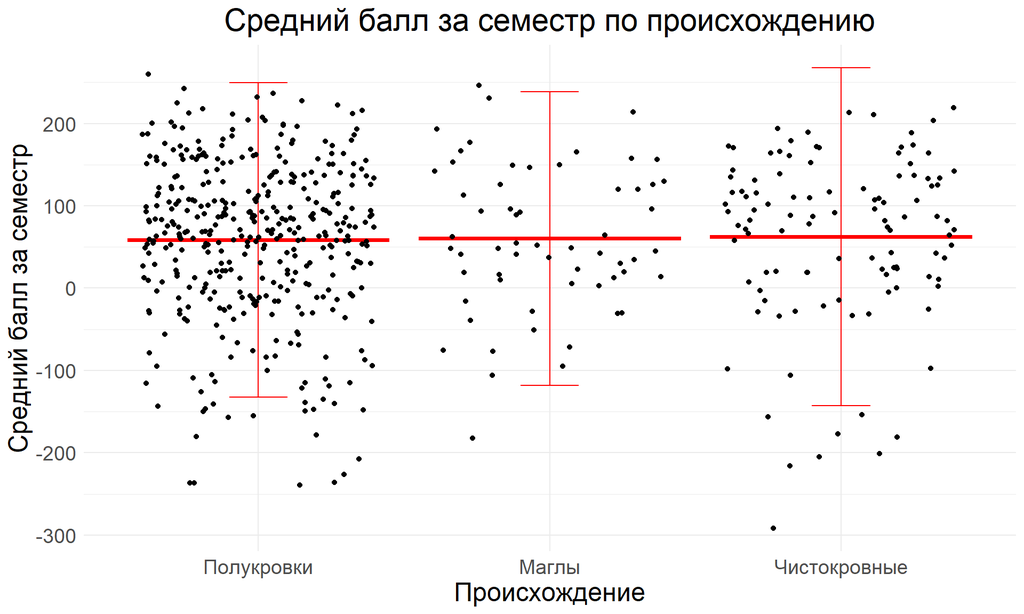

```r
data %>%
  ggplot(aes(x = bloodStatus, y = result)) +
  stat_summary(fun = mean, geom = "crossbar", color = "red") +
  stat_summary(fun.data = mean_sdl, geom = "errorbar", width = 0.2, color = "red") +
  geom_jitter() +
  labs(title = "Средний балл за семестр по происхождению",
       x = "Происхождение",
       y = "Средний балл за семестр") +
  theme_minimal() +
  theme(text = element_text(size = 18),
        plot.title = element_text(hjust = 0.5)) +
  scale_x_discrete(labels = c("muggle-born" = "Маглы",
                              "half-blood" = "Полукровки",
                              "pure-blood" = "Чистокровные"))
```

**При этом, средний балл по всем эказменам у маглов не ниже, чем у остальных.** **Возможно, низкий балл по зельеварению связан с тем, что препод по зельеварению хуже относится к маглам.**

## Воспроизведение графика

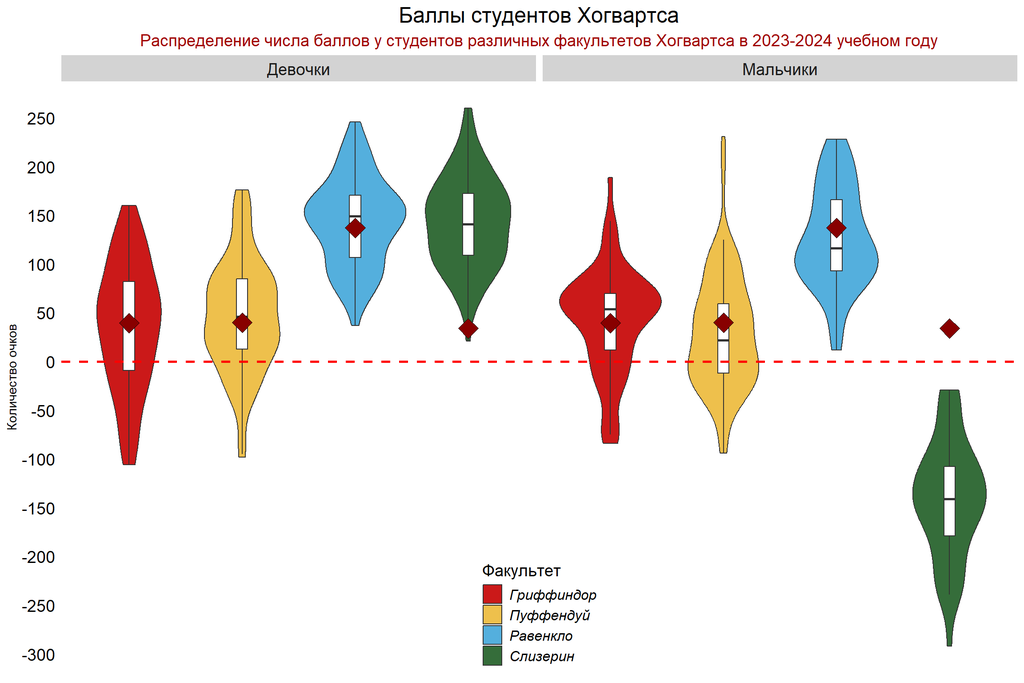

```r
mean_values <- data %>% # средние значения по факультетам независимо от пола (ромбики)
  mutate(house = recode(house,
                        `Gryffindor` = "Гриффиндор",
                        `Hufflepuff` = "Пуффендуй",
                        `Ravenclaw` = "Равенкло",
                        `Slytherin` = "Слизерин")) %>%
  group_by(house) %>%
  summarise(mean_result = mean(result, na.rm = TRUE))

data %>%
  mutate(house = recode(house,
                        `Gryffindor` = "Гриффиндор",
                        `Hufflepuff` = "Пуффендуй",
                        `Ravenclaw` = "Равенкло",
                        `Slytherin` = "Слизерин"),
         sex = recode(sex,
                      `female` = "Девочки",
                      `male` = "Мальчики")) %>%
  ggplot(aes(x = house, y = result, fill = house)) +
  geom_violin(trim = TRUE, alpha = 0.9) +
  geom_boxplot(width = 0.1, fill = "white", outlier.shape = NA) +
  geom_hline(yintercept = 0, linetype = "dashed", color = "red", size = 1) +
  geom_point(data = mean_values, aes(x = house, y = mean_result),
             color = "black", shape = 23, fill = "#800", size = 6) +  # Средние значения по факультетам
  scale_fill_manual(values = c("Гриффиндор" = "#C50000",
                               "Пуффендуй" = "#ECB939",
                               "Равенкло" = "#41A6D9",
                               "Слизерин" = "#1F5D25")) +
  scale_y_continuous(breaks = seq(-300, 250, by = 50)) +
  labs(
    title = "Баллы студентов Хогвартса",
    subtitle = "Распределение числа баллов у студентов различных факультетов Хогвартса в 2023-2024 учебном году",
    x = NULL, y = "Количество очков",
    fill = "Факультет"
  ) +
  theme_minimal() +
  theme(axis.text.x = element_blank(),
        panel.grid = element_blank(),
        axis.text.y = element_text(size = 14, color = "black"),
        plot.title = element_text(size = 18, hjust = 0.5),
        plot.subtitle = element_text(size = 14, hjust = 0.5, color = "#A00000"),
        legend.title = element_text(size = 14),
        legend.text = element_text(size = 12, face = "italic"),
        panel.grid.major.x = element_blank(),
        strip.background = element_rect(fill = "#D3D3D3", color = "NA"),
        strip.text = element_text(size = 14),
        legend.position = c(0.5, 0.1)) +
  facet_grid(. ~ sex)
```